# MB Sex Differences in DNA Methylation in subgroups - call CNVs

Rachel Moss

June 27, 2022

## Introduction

I will use [conumee](https://bioconductor.org/packages/release/bioc/html/conumee.html) to call copy number variations (CNVs) from the Illumina 450k methylation arrays in the Newcastle and the Cavalli datasets. The GSE15745 healthy brain dataset does not have idat files available, so I will use the normal cerebellum samples from GSE134379 instead for the controls for the CNV analysis.

## Setup

### Load packages

```r
library(minfi)
library(conumee)
library(GEOquery)
library(tidyverse)
library(readr)
library(filesstrings)
```

### Specify files and paths

These Newcastle files are stored on a shared [google drive](https://drive.google.com/drive/folders/1QakbU5kqgWX5cQIPI64F8srgZbKbhDLj?usp=sharing). The healthy brain data will be downloaded from GEO.

```r
# Set the directory where the processed data will be kept
rawdata <- "/Volumes/GoogleDrive/My Drive/Research/SexDiffMedullo/Analysis_RMM_new/data/raw"
procData <- "/Volumes/GoogleDrive/My Drive/Research/SexDiffMedullo/Analysis_RMM_new/data/processed"
controlGSE <- "GSE134379"
phenoNewFile <- "Newcastle_pheno_v3.csv"

# # Set the directory where the counts files are found
# counts_dir <- here::here("analyses", "mutation_counts")
#
# # File paths to the counts files for LGAT and medulloblastoma
# lgat_path <- file.path(counts_dir, "LGAT_gene-mutations.tsv")
# mb_path <- file.path(counts_dir, "Medulloblastoma_gene-mutations.tsv")
#
# # Reference directory & FLAGS (frequently mutated genes)
# ref_dir <- here::here("data", "reference")
# flags_path <- file.path(ref_dir, "FLAGS.txt")
```

Outputs

```r
# set the directory to save output plots
results_dir <- "./results"

# create the results directory if it does not exist
if (!dir.exists(results_dir)){
  dir.create(results_dir, recursive = TRUE)
}
```

### Download Data

```r
# #download GEO object
# gseCtrl <- getGEO(controlGSE, GSEMatrix = TRUE)
# #get phenotype data - sample sheet
# pd = pData(gseCtrl[[1]])
# pd_filt <- pd[,c("geo_accession","title","source_name_ch1","supplementary_file","supplementary_file.1","age:ch1","bead chip:ch1","brain region:ch1","diagnosis:ch1","gender:ch1","plate:ch1","tissue:ch1","well position:ch1")]
# pd_filt$filename <- sub(".*suppl/","",pd$supplementary_file)
# pd_filt$Basename <- sub("_Grn.idat.gz","",pd_filt$filename)
# pd_filt <- pd_filt %>%
#   separate(col=Basename,into=c("GSM","Sentrix_ID","Sentrix_Position"),sep="_",remove=FALSE)
# rownames(pd_filt) <- pd_filt$geo_accession
# colnames(pd_filt) <- c("Sample_Name","Title","Source_Name","supplementary_file","supplementary_file.1","Age","Bead_Chip","Brain_Region","Sample_Group","Sex","Sample_Plate","Tissue","Sample_Well","filename","Basename","GSM","Sentrix_ID","Sentrix_Position")
# pd_filt$MSA_Well <- NA
# pd_filt$Pool_ID <- NA
# pd_filt <- pd_filt[,c("Sample_Name","Sample_Well","MSA_Well","Sample_Plate","Sample_Group","Pool_ID","Sentrix_ID","Sentrix_Position","Basename","Title","Source_Name","supplementary_file","supplementary_file.1","Age","Bead_Chip","Brain_Region","Sex","Tissue","GSM","filename")]
# #write_csv(pd_filt, file=paste0(procData,"/",controlGSE,"_pheno.csv"))
# pd_normCBL <- pd_filt %>%
#   filter(Sample_Group=="ND" & Brain_Region=="CBL")
# # write_csv(pd_normCBL, file=paste0(rawdata,"/control_",controlGSE,"/idat/","Control_CBL_",controlGSE,"_pheno_Sample_Sheet.csv"))

# #decompress idats
# dir <- paste0(rawdata,"/control_",controlGSE,"/")
# untar(paste0(dir,controlGSE,"_RAW.tar"), exdir = paste0(dir,"/idat"))
# #list files
# head(list.files(paste0(dir,"/idat"), pattern = "idat"))
# idatFiles <- list.files(paste0(dir,"/idat"), pattern = "idat.gz$", full = TRUE)
# #norm_idatFiles <- paste0(dir,"idat/",pd_normCBL$filename)
# #decompress individual idat files only the CBL and non diseased samples
# sapply(idatFiles, gunzip, overwrite = TRUE)
#
# # Find sample sheet with phenotype info, csv file
# targets <- read.metharray.sheet(rawdata, pattern = "Sample_Sheet.csv")
#
# # Create RGChannelSet object that contains raw intensities in the green and red channels, including internal control probes
# RGSet_Ctrl <- read.metharray.exp(targets = targets, verbose = T)
# RGSet_Ctrl
# saveRDS(RGSet_Ctrl, paste0(procData,"/RGSet_control_CBL_",controlGSE,".RDS"))
#
# # Create methylset
# Mset_Ctrl <- preprocessRaw(RGSet_Ctrl)
# saveRDS(Mset_Ctrl, paste0(procData,"/MSet_control_CBL_",controlGSE,".RDS"))
#
# RGSet_New <- readRDS(paste0(procData,"/RGSet_GSE93646_filt.RDS"))
#
# # Create methyl set
# MSet_new <- preprocessRaw(RGSet_New)
# saveRDS(MSet_new, paste0(procData,"/MSet_Newcastle_GSE93646_filt.RDS"))
```

### Define functions

No functions right now

## Use Conumee to call CNVs for Newcastle

Now that we have done all of our setup, we can move on to the CNV analysis using conumee

### Reading data

We’ll first read in the data for Newcastle and control data as methylsets. I’ll also read in the pheno data for Newcastle that contains subgroups

```r
MSet_New <- readRDS(paste0(procData,"/MSet_Newcastle_GSE93646_filt.RDS"))
phenoNew <- pheno <- read_csv(paste0(procData,"/Newcastle/",phenoNewFile))
Mset_Ctrl <- readRDS(paste0(procData,"/MSet_control_CBL_GSE134379.RDS"))
```

### Quick stats

Describe the data we have.

```r
cat("Newcastle data contains:", ncol(MSet_New),"medulloblastoma samples")
```

```
## Newcastle data contains: 407 medulloblastoma samples
```

```r
cat("\n") # print return between
```

```r
cat("Counts of Newcastle samples by subgroup: ")
```

```
## Counts of Newcastle samples by subgroup:
```

```r
table(phenoNew$subgroup)
```

```
##
## Group3 Group4    SHH    WNT
##     96    148     88     29
```

```r
cat("Control data contains:", ncol(Mset_Ctrl), "samples")
```

```
## Control data contains: 179 samples
```

### Create annotation object

```r
data(exclude_regions)
data(detail_regions)
head(detail_regions, n = 2)
```

```
## GRanges object with 2 ranges and 5 metadata columns:
##       seqnames            ranges strand |        name             thick
##          <Rle>         <IRanges>  <Rle> | <character>         <IRanges>
##   [1]    chr11 69453874-69469242      + |       CCND1 68961558-69961557
##   [2]    chr19 30300902-30315215      + |       CCNE1 29808059-30808058
##           score probes_gene probes_promoter
##       <integer>   <integer>       <integer>
##   [1]        70          38              32
##   [2]        16          10               6
##   -------
##   seqinfo: 11 sequences from an unspecified genome; no seqlengths
```

```r
anno <- CNV.create_anno(array_type = "450k", exclude_regions = exclude_regions, detail_regions = detail_regions)
```

```
## using genome annotations from UCSC
```

```
## getting 450k annotations
```

```
##  - 470870 probes used
```

```
## importing regions to exclude from analysis
```

```
## importing regions for detailed analysis
```

```
## creating bins
```

```
##  - 53891 bins created
```

```
## merging bins
```

```
##  - 15820 bins remaining
```

```r
anno
```

```
## CNV annotation object
##    created  : Tue Jun 28 20:29:17 2022
##   @genome   : 22 chromosomes
##   @gap      : 313 regions
##   @probes   : 470870 probes
##   @exclude  : 3 regions (overlapping 570 probes)
##   @detail   : 20 regions (overlapping 768 probes)
##   @bins     : 15820 bins (min/avg/max size: 50/168.5/5000kb, probes: 15/29.7/478)
```

### Combine intensity values

```r
#data(tcgaBRCA.sentrix2name)  # TCGA sample IDs are supplied with the conumee package
#sampleNames(MsetTCGA) <- tcgaBRCA.sentrix2name[sampleNames(MsetTCGA)]
Newcastle.data <- CNV.load(MSet_New)
controls.data <- CNV.load(Mset_Ctrl)
names(Newcastle.data)
```

```
##   [1] "GSM2459424_7973201043_R02C01" "GSM2459425_7973201043_R05C02"
##   [3] "GSM2459426_9422491032_R02C02" "GSM2459427_7973201126_R01C02"
##   [5] "GSM2459428_9421912022_R05C02" "GSM2459429_9421912022_R06C02"
##   [7] "GSM2459430_9421912024_R01C02" "GSM2459431_9421912024_R01C01"
##   [9] "GSM2459432_9421912022_R03C02" "GSM2459433_7878191130_R01C01"
##  [11] "GSM2459434_7973201123_R01C01" "GSM2459435_7973201076_R03C01"
##  [13] "GSM2459436_9647455136_R02C01" "GSM2459437_7878191130_R03C02"
##  [15] "GSM2459438_6026818065_R01C02" "GSM2459439_7970368039_R02C02"
##  [17] "GSM2459440_7973201126_R05C01" "GSM2459441_9647455180_R01C02"
##  [19] "GSM2459442_9422491032_R06C01" "GSM2459443_7973201008_R04C01"
##  [21] "GSM2459444_6026818065_R02C02" "GSM2459445_9647455136_R03C01"
##  [23] "GSM2459446_7973201051_R01C01" "GSM2459447_7973201051_R04C01"
##  [25] "GSM2459448_9647455137_R01C01" "GSM2459449_6222421011_R01C02"
##  [27] "GSM2459450_6026818126_R04C01" "GSM2459451_7970368039_R05C01"
##  [29] "GSM2459452_7973201008_R02C01" "GSM2459453_9647455136_R05C02"
```

[output cut: 189 more lines]

```r
## [1] "TCGA-AR-A1AU-01A-11D-A12R-05" "TCGA-AR-A1AY-01A-21D-A12R-05"
Newcastle.data
```

```
## CNV data object
##    created   :
##   @intensity : available (407 samples, 485512 probes)
```

```r
## CNV data object
##    created   :
##   @intensity : available (2 samples, 485512 probes)

# minfi.data <- CNV.load(MsetEx)
# minfi.controls <- pData(MsetEx)$status == "normal"
# controls.data <- CNV.load(MsetControls)
```

### Main CNV Analysis

```r
x <- CNV.fit(Newcastle.data["GSM2459851_9761749073_R04C01"], controls.data, anno)
# y <- CNV.fit(tcga.data["TCGA-AR-A1AU-01A-11D-A12R-05"], controls.data, anno)  # CopyNumber450kData package is deprecated
# z <- CNV.fit(tcga.data["TCGA-AR-A1AY-01A-21D-A12R-05"], controls.data, anno)
# y <- CNV.fit(tcga.data["TCGA-AR-A1AU-01A-11D-A12R-05"], minfi.data[minfi.controls], anno)  # minfiData control samples
# z <- CNV.fit(tcga.data["TCGA-AR-A1AY-01A-21D-A12R-05"], minfi.data[minfi.controls], anno)

x <- CNV.bin(x)
x <- CNV.detail(x)
x <- CNV.segment(x)

# y <- CNV.segment(CNV.detail(CNV.bin(y)))
# z <- CNV.segment(CNV.detail(CNV.bin(z)))

x
```

```
## CNV analysis object
##    created   : Tue Jun 28 20:39:20 2022
##   @name      : GSM2459851_9761749073_R04C01
##   @anno      : 22 chromosomes, 470870 probes, 15820 bins
##   @fit       : available (noise: 0.309)
##   @bin       : available (shift: 0.025)
##   @detail    : available (20 regions)
##   @seg       : available (57 segments)
```

### Output plots and text files

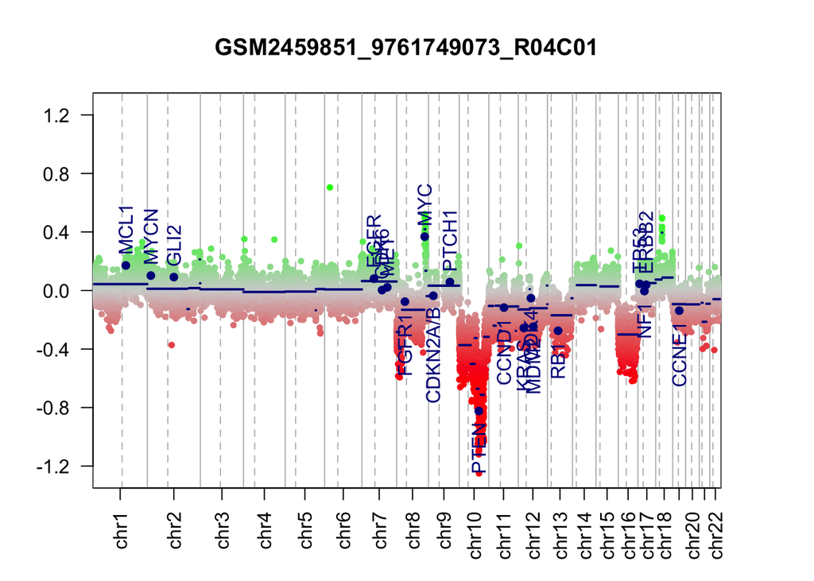

```r
#pdf("~/conumee_analysis/CNVplots.pdf", height = 9, width = 18)
CNV.genomeplot(x)
```

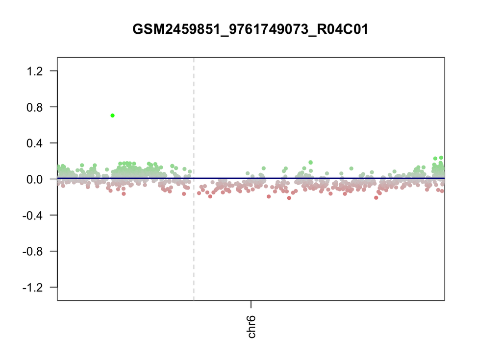

```r
CNV.genomeplot(x, chr = "chr6")
```

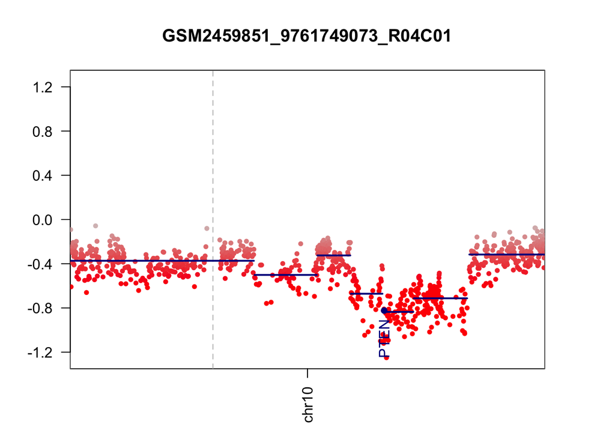

```r
CNV.genomeplot(x, chr = "chr10")
```

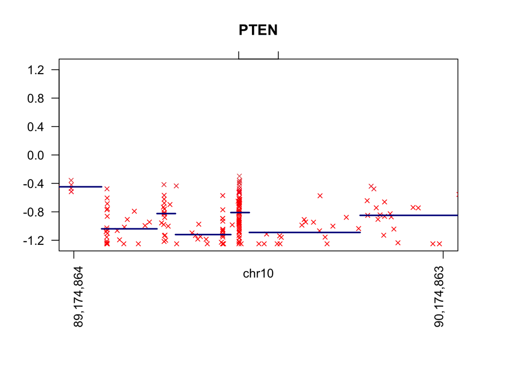

```r
CNV.detailplot(x, name = "PTEN")
```

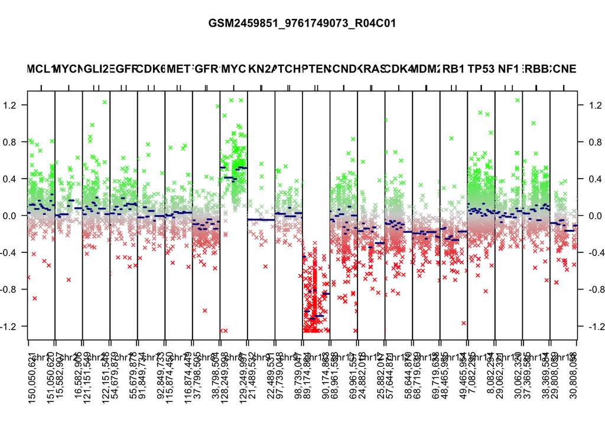

```r
CNV.detailplot_wrap(x)
```

```r
#dev.off()

head(CNV.write(x, what = "segments"), n = 5)
```

|  | ID | chrom | loc.start | loc.end | num.mark | bstat | pval | seg.mean | seg.median |
| --- | --- | --- | --- | --- | --- | --- | --- | --- | --- |
| 1 | GSM2459851_9761749073_R04C01 | chr1 | 635684 | 249195311 | 1593 | NA | NA | 0.044 | 0.044 |
| 2 | GSM2459851_9761749073_R04C01 | chr10 | 105000 | 52450000 | 297 | 8.552724 | 1.577401e-15 | -0.375 | -0.373 |
| 3 | GSM2459851_9761749073_R04C01 | chr10 | 52650000 | 70425000 | 53 | 9.547195 | 1.163393e-19 | -0.505 | -0.501 |
| 4 | GSM2459851_9761749073_R04C01 | chr10 | 70575000 | 80000000 | 82 | 15.489468 | 4.469524e-52 | -0.338 | -0.325 |
| 5 | GSM2459851_9761749073_R04C01 | chr10 | 80125000 | 89175000 | 44 | 6.133327 | 4.403215e-08 | -0.686 | -0.672 |

### Saving plots

```r
# ggsave(
#   file.path(plots_dir, "LGAT_mutation-counts.png"),
#   lgat_plot,
#   width = 7,
#   height = 7
# )
# ggsave(
#   file.path(plots_dir, "Medulloblastoma_mutation-counts.png"),
#   mb_plot,
#   width = 7,
#   height = 7
# )
```

## Session information

We like to end all of our notebooks with a call to a function that provides a brief report about the versions of R and all packages that were used in the notebook. This can be very useful for debugging down the line, as different versions of packages, R, or even the operating system can sometimes result in slightly or significantly differen outputs.

The most common such function is `sessionInfo()`, which is part of base R and is what we are using here, but a nice alternative is the function `sessioninfo::session_info()` (part of the `sessioninfo` package), which provides a somewhat more neatly-formatted report with a bit more information.

[session information not shown]